# Melancholie des Widerstands

## Handlung

In einer abgelegenen Kleinstadt irgendwo in Europa herrschen unheimliche Zustände. Überfüllte Züge verschwinden im Nichts, die Wurzeln der umgefallenen Pappel ragen bis zum Himmel, Abfall haftet auf den Gehwegen der Straßen, über die sich eine Dunkelheit legt. Rosi Pflaum, eine verwitwete Hausfrau, befürchtet nach einer entblößenden Begegnung im Zug das Schlimmste – für sich selbst und für die Stadt. Verängstigt sucht sie Schutz in ihrer Wohnung, in der das kitschige Interieur zum Rückzugsort wird. Für die Dauer einer Operette gerät das unberechenbare Draußen kurz in Vergessenheit.

Ein Refugium hat sich auch Georges Esther zurechtgelegt, der sein angesehenes Amt als Musikschuldirektor der Stadt niedergelegt hat, um sich ganz seinen Forschungen am Klavier zu widmen. Besessen von dem Gedanken, die europäische Musikgeschichte sei seit der Idee und praktischen Umsetzung der Wohltemperierung verfälscht, stimmt er sein Klavier zurück zur »wirklichen Stimmung« und versucht damit, seine Vision der Ordnung der Welt klanglich wiederherzustellen.

Seine Noch-Ehefrau Angèle Esther hat er vor die Tür gesetzt und damit vor den Kopf gestoßen. Madame Esther, die ehemalige Dirigentin eines Männerchors, ist eine Frau der Tat. Mit ihrer Aufräum-Aktion »Gekehrtes Heim, Ordnung muss sein« möchte sie die Stadt zur gewohnten Ordnung zurückführen. Doch sie weiß: Um die Menschen der Stadt von ihrem Plan zu überzeugen, benötigt sie das Ansehen ihres Mannes. Sie erpresst ihn und droht damit, in die gemeinsame Wohnung zurück zu kehren. Ihr Plan geht auf – Monsieur Esther schließt sich der Aktion gegen seinen Willen an und hofft im Gegenzug, seine Frau damit ein für allemal loszuwerden.

Bindeglied zwischen dem getrennten Ehepaar ist Madame Pflaums Sohn Valouchka. Er ist der Briefträger der Stadt und bringt Monsieur Esther täglich sein Essen, seine Post und holt die schmutzige Wäsche, die ihm seine Noch-Ehefrau weiterhin wäscht. Der kindlich gebliebene Sonderling ist von dem zurückgezogenen Gelehrten fasziniert. Für Monsieur Esther wiederum ist Valouchka nicht nur der einzige Kontakt zur Außenwelt, sondern stellt in seiner Naivität und Bewunderung für die Schönheit des Universums ein erstrebenswertes Ideal dar.

Für Valouchka, der ein angespanntes Verhältnis zu seiner Mutter hat, ist die Kneipe »Le Péfeffer«ein zweites Zuhause. Jeden Abend kurz bevor das Lokal schließt, fordern ihn die Trinker auf, mit ihnen die Sonnenfinsternis durchzuspielen und den Abend damit noch etwas in die Länge zu ziehen. Für die Vorführung dieses Naturspektakels ordnet Valouchka drei Gäste als Sonne, Mond und Erde im Raum an und lässt sie um sich kreisen … solange, bis sich der Mond zwischen Sonne und Erde schiebt und sich alles verfinstert. Valouchkas Veranschaulichung wird zur bildhaften Vorahnung des finsteren Schattens, der sich über die Kleinstadt legt.

Mit der Ankunft einer mysteriösen Schausteller-Truppe wird eine dunkle, unkontrollierbare Energie freigesetzt. Ein riesiger Wal und ein winziger Herzog sind die Hauptattraktionen des Zirkus. Während die majestätische Größe des Wals von den Bewohnern der Stadt bewundert wird, tritt der Herzog selbst nicht in Erscheinung. Lediglich seine Stimme wird von einem Faktotum übersetzt. Was er zu verlauten hat, ist verheerend: Er ist gekommen, um zu richten, und er ist nicht allein. Seine mysteriöse Erscheinung strahlt eine unheimliche Faszination auf die Menschen der Stadt aus. Sie schließen sich ihm an und bilden gemeinsam mit seinen Anhängern – den Männern in Stoffmänteln – eine aufrührerische Bewegung, die das bestehende System stürzen will. Chaos bricht aus, die Stadt wird angegriffen und demoliert. Das, was sich längst angebahnt hatte, ist nun eingetreten: Die Welt ist aus den Fugen geraten. Und Valouchka ist Zeuge.

Madame Esther nutzt das Chaos für ihre Zwecke. Sie setzt die Polizei außer Kraft, übergeht die Bürger und verbündet sich mit dem Militär. Valouchkas Versuch, seine Mutter vor den Randalierern zu warnen, scheitert. Denn Madame Pflaum glaubt nicht an den Ernst der Lage, macht ihrem Sohn Vorwürfe und muss dann beobachten, wie er von den Männern in Stoffmänteln mitgenommen wird. Ungeachtet seiner selbst wird Valouchka Teil der Bewegung und verspürt zum ersten Mal in seinem Leben ein Gefühl von Zugehörigkeit – trotz der Sorge um seine Mutter und um Monsieur Esther.

Beide – Madame Pflaum und Monsieur Esther – machen sich auf die Suche nach dem Jungen. Doch Rosi Pflaum wird Opfer der gewaltvollen Machtübernahme. Madame Esther wird sie an ihrem Sarg später zynisch als »Heldin« bezeichnen, die Widerstand leistete. Madame Esther fährt schließlich erhobenen Hauptes mit dem General ab.

Auch Monsieurs Esthers Suche nach Valouchka bleibt ohne Erfolg. Am Ende kehrt er gezeichnet an sein Klavier zurück; Valouchka kann fliehen.

## Pressestimmen

> »Dass Dalbavie, der Komponist, diese Rolle [Valouchka] mit einem Countertenor besetzt hat, ist ein gelungener Kunstkniff, dass Philippe Jaroussky diese Rolle übernimmt, ein Glücksfall für die Inszenierung. Seine satt leuchtende Stimme, die kein Falsch und Böse kennt, verleiht dem Valouchka eine Strahlkraft von himmlischer Naivität.«

> **Frankfurter Allgemeine Zeitung, 2. Juli 2024**

> »Musikalisch ist es eine Spitzenleistung!«

> **Deutschlandfunk, 1. Juli 2024**

> »Diese Filmästhetik und die unglaublich präzise Arbeit von Marton und seinen Mitstreitern bringt einem die Geschichte auf eine sinnvolle und sinnliche Weise nahe. Man ist jeden Moment gebannt und gespannt.«

> **Deutschlandfunk, 1. Juli 2024**

> »Sie [Marie Jacquot] und die Berliner Staatskapelle durchleuchten die großflächig angelegte Orchestermusik mit einem Enthusiasmus, der Transparenz jederzeit mit einschließt.«

> **Süddeutsche Zeitung, 2. Juli 2024**

## Programmbuch

[Download](https://www.staatsoper-berlin.de/downloads-b/de/produktion/12157/programmbuch/692d5afd70ac4f0d77c0c11a2d941601/Melancholie_Programmbuch_30062024++dt-Libretto_gesch.pdf)

## Mehr erfahren

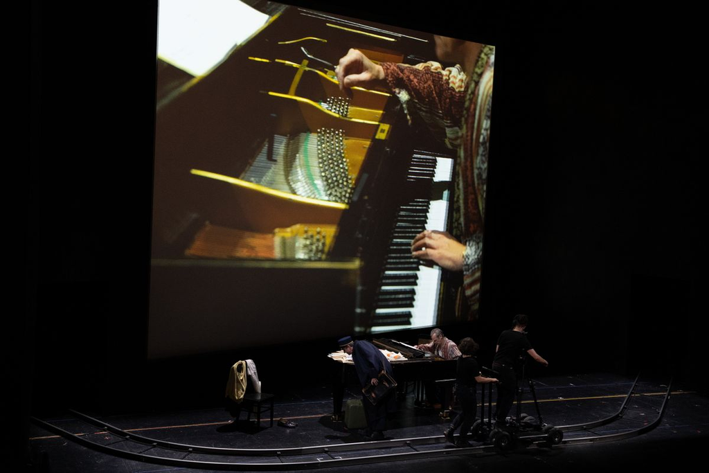

- Ein Gespräch mit Regisseur David Marton, Videokünstler Chris Kondek und Librettist Guillaume Métayer.

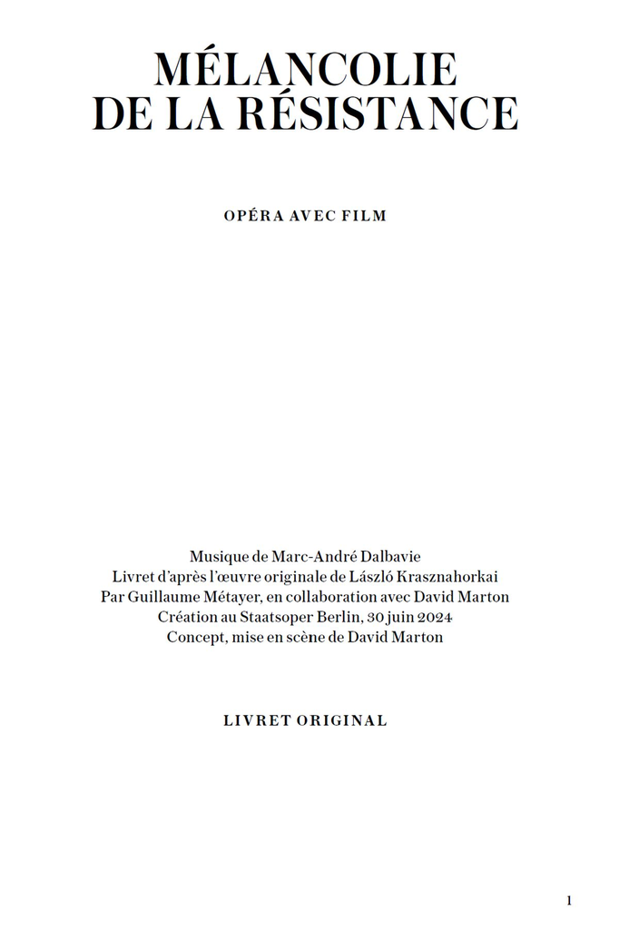

[interactive chart not shown]